# RRspread

Hsueh-Chien Raymond Cheng

05/02/2024

**This is the markdown file for generate results for Israel relative risk of spread manuscript**

### Install RRspread package from github

```r
devtools::install_github("hsuehchien66/rrspread_v2")
```

### Load libraries

```r
library(ape)
library(BactDating)
library(dplyr)
library(geosphere)
library(ggplot2)
library(data.table)
library(cowplot)
library(rrspread)
```

### Load input data

```r
metadata_file_path = "/Users/hc14/Documents/SpneumoIsrael/Israel_raw_data/input/Israel_1174isolates_metadata_input.txt"
metadata = read.csv(metadata_file_path, sep="\t")
metadata = metadata[, c("lane_id", "GPSC_PoPUNK2", "REGION", "Longitude", "Latitude", "Year_collection")]
```

### Load Gubbins tree

The tree should be recombination-corrected by Gubbins GPSC6,8,10,47,55 are selected for Israel migration analysis

```r
gpsc8_gubbin_tree_path = "/Users/hc14/Documents/SpneumoIsrael/analysis_results/05_topGPSC_gubbin_output_tree/GPSC8_reference_bwa.final_tree.tre"
  gpsc8_gubbin_tree = read.tree(gpsc8_gubbin_tree_path)

gpsc55_gubbin_tree_path = "/Users/hc14/Documents/SpneumoIsrael/analysis_results/05_topGPSC_gubbin_output_tree/GPSC55_reference_bwa.final_tree.tre"
  gpsc55_gubbin_tree = read.tree(gpsc55_gubbin_tree_path)

gpsc47_gubbin_tree_path = "/Users/hc14/Documents/SpneumoIsrael/analysis_results/05_topGPSC_gubbin_output_tree/GPSC47_reference_bwa.final_tree.tre"
  gpsc47_gubbin_tree = read.tree(gpsc47_gubbin_tree_path)

gpsc6_gubbin_tree_path = "/Users/hc14/Documents/SpneumoIsrael/analysis_results/05_topGPSC_gubbin_output_tree/GPSC6_reference_bwa.final_tree.tre"
  gpsc6_gubbin_tree = read.tree(gpsc6_gubbin_tree_path)

gpsc10_gubbin_tree_path = "/Users/hc14/Documents/SpneumoIsrael/analysis_results/05_topGPSC_gubbin_output_tree/GPSC10_reference_bwa.final_tree.tre"
  gpsc10_gubbin_tree = read.tree(gpsc10_gubbin_tree_path)
```

### Run BactDating (time-consuming)

**Input:**  
1. Gubbins (recombination-corrected tree),  
2. metadata with collection time  
**Output:**  
1. bactdating results  
2. root-to-tip distance vs. collection time  
**Notes:**  
In **match_tree_meta()**, *drop_tip= TRUE* to make sure reference genome is not included in the analysis,  
In **time_resolved()**, *branch_model* can be assigned for evolutionary rates of branches,  
In **time_resolved()**, *n_it* to assign number of iterations in the MCMC process

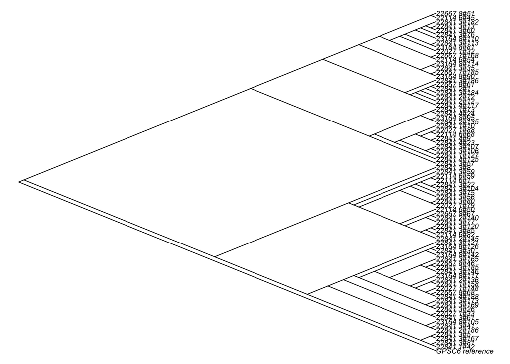

```r
gpsc6_gubbin_tree_plot = plt_gubbin_tree(gpsc6_gubbin_tree)
```

```r
gpsc6_time_tree_list = match_tree_meta(metadata, gpsc6_gubbin_tree, "GPSC6_reference", drop_tip = TRUE)
gpsc6_bd_res = time_resolved(gpsc6_time_tree_list$match_tree_meta, gpsc6_time_tree_list$tree, "/Users/hc14/Documents/SpneumoIsrael/analysis_results/bd_res_GPSC6", n_it = 3000, branch_model="mixedgamma")
```

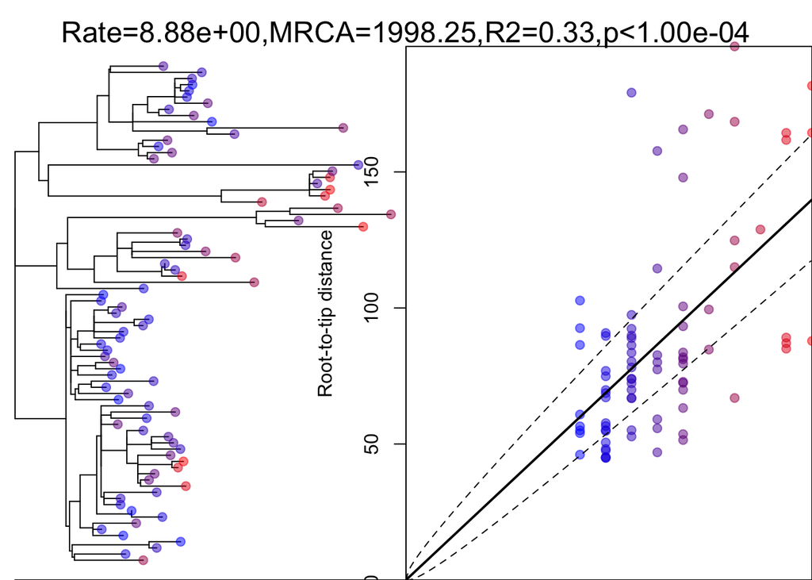

```r
### or Load previous bactdating results
load(file = "/Users/hc14/Documents/SpneumoIsrael/analysis_results/bdtree_mixgamma.RData")
```

```r
gpsc6_bd_res
```

```
## $Root2Tip
## $Root2Tip$rate
##     date
## 8.878975
##
## $Root2Tip$ori
## (Intercept)
##    1998.252
##
## $Root2Tip$pvalue
## [1] 0
##
##
## $BactDating
## Phylogenetic tree dated using BactDating
##
## Phylogenetic tree with 81 tips and 80 internal nodes.
##
## Tip labels:
##   22841_1#42, 22841_3#81, 22841_3#167, 22841_3#5, 22841_2#186, 22841_3#41, ...
##
## Rooted; includes branch lengths.
## Probability of root branch=0.44
## likelihood=-5.01e+02 [-5.26e+02;-4.80e+02]
## prior=-4.79e+02 [-5.19e+02;-4.51e+02]
## mu=3.41e+00 [2.21e+00;4.70e+00]
## sigma=2.16e+00 [1.22e+00;3.36e+00]
## alpha=1.51e+02 [9.37e+01;2.45e+02]
## Root date=1948.67 [1877.20;1978.52]
## Root date for most likely root=1945.12 [1889.97;1973.63]
```

#### Checked convergence of MCMC

**Notes:** 3 parameters (mu, sigma, alpha) should get converged and have enough sample size throughout MCMC. Each parameter should have sample size > 100

```r
mcmc_gpsc6=as.mcmc.resBactDating(gpsc6_bd_res$BactDating) #check whether converge
coda::effectiveSize(mcmc_gpsc6)
```

```
##       mu    sigma    alpha
## 109.9898 150.5795 111.2693
```

### Bind trees and combine trees with metadata

Match the laneid in the tips of the trees and the laneid in the metadata

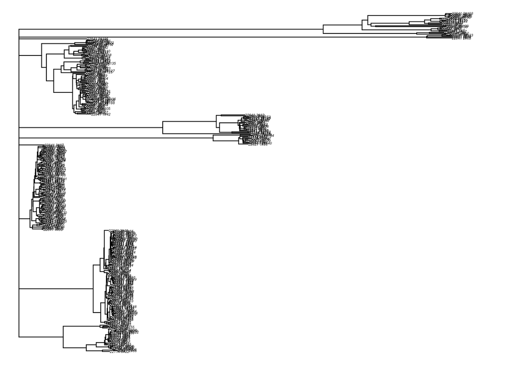

```r
gpsc08_bd_tree = gpsc8_bd_res$BactDating$tree
gpsc55_bd_tree = gpsc55_bd_res$BactDating$tree
gpsc47_bd_tree = gpsc47_bd_res$BactDating$tree
gpsc06_bd_tree = gpsc6_bd_res$BactDating$tree
gpsc10_bd_tree = gpsc10_bd_res$BactDating$tree


multitrees = bind_multitree(gpsc08_bd_tree, gpsc55_bd_tree, gpsc47_bd_tree, gpsc06_bd_tree, gpsc10_bd_tree)
plot(multitrees, cex=0.3, no.margin = TRUE)
```

```r
lanes <- multitrees$tip.label

## subset only those present in the trees
####metadata = read.csv(metadata_file)
selected_gpsc_metadata = subset(metadata, metadata$lane_id %in% lanes)
lanes_gpsc <- subset(lanes, lanes  %in% selected_gpsc_metadata$lane_id)
multitrees_overall <- keep.tip(multitrees, lanes_gpsc)

#Reorder tree based on order of tip labels
order <- multitrees_overall$tip.label
selected_gpsc_metadata <- selected_gpsc_metadata %>%
  dplyr::slice(match(order, lane_id))
```

### Load Metadata of GPSC6,8,10,47,55

```r
gpsc6_metadata <- selected_gpsc_metadata[which(selected_gpsc_metadata$GPSC_PoPUNK2 == "6"),]
gpsc8_metadata <- selected_gpsc_metadata[which(selected_gpsc_metadata$GPSC_PoPUNK2 == "8"),]
gpsc10_metadata <- selected_gpsc_metadata[which(selected_gpsc_metadata$GPSC_PoPUNK2 == "10"),]
gpsc47_metadata <- selected_gpsc_metadata[which(selected_gpsc_metadata$GPSC_PoPUNK2 == "47"),]
gpsc55_metadata <- selected_gpsc_metadata[which(selected_gpsc_metadata$GPSC_PoPUNK2 == "55"),]
```

### Generate matrices for relative risk calculations for each GPSC

**Input:**  
1. Metadata,  
2. Bactdating results  
**Output:**  
11 matrices for following relative risk calculations

```r
gpsc6_rrmatrix <- RR_matrix(meta_table = gpsc6_metadata, bactdate_tree = gpsc6_bd_res$BactDating$tree, ref_distance_min = 0)
gpsc8_rrmatrix <- RR_matrix(meta_table = gpsc8_metadata, bactdate_tree = gpsc8_bd_res$BactDating$tree, ref_distance_min = 0)
gpsc10_rrmatrix <- RR_matrix(meta_table = gpsc10_metadata, bactdate_tree = gpsc10_bd_res$BactDating$tree, ref_distance_min = 0)
gpsc47_rrmatrix <- RR_matrix(meta_table = gpsc47_metadata, bactdate_tree = gpsc47_bd_res$BactDating$tree, ref_distance_min = 0)
gpsc55_rrmatrix <- RR_matrix(meta_table = gpsc55_metadata, bactdate_tree = gpsc55_bd_res$BactDating$tree, ref_distance_min = 0)
```

### Distance vs. Divergence time relationship

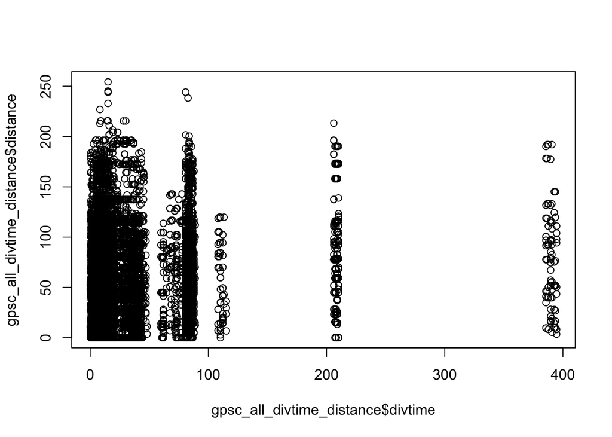

```r
### GPSC6
gpsc6_distance_dist <- as.data.frame(to.upper(gpsc6_rrmatrix$distance_num_mat))
gpsc6_divtime_dist <- as.data.frame(to.upper(gpsc6_rrmatrix$divtime_num_mat))
gpsc6_divtime_distance <- cbind(gpsc6_divtime_dist, gpsc6_distance_dist)
colnames(gpsc6_divtime_distance) <- c("divtime", "distance")

### GPSC8
gpsc8_distance_dist <- as.data.frame(to.upper(gpsc8_rrmatrix$distance_num_mat))
gpsc8_divtime_dist <- as.data.frame(to.upper(gpsc8_rrmatrix$divtime_num_mat))
gpsc8_divtime_distance <- cbind(gpsc8_divtime_dist, gpsc8_distance_dist)
colnames(gpsc8_divtime_distance) <- c("divtime", "distance")

### GPSC10
gpsc10_distance_dist <- as.data.frame(to.upper(gpsc10_rrmatrix$distance_num_mat))
gpsc10_divtime_dist <- as.data.frame(to.upper(gpsc10_rrmatrix$divtime_num_mat))
gpsc10_divtime_distance <- cbind(gpsc10_divtime_dist, gpsc10_distance_dist)
colnames(gpsc10_divtime_distance) <- c("divtime", "distance")

### GPSC47
gpsc47_distance_dist <- as.data.frame(to.upper(gpsc47_rrmatrix$distance_num_mat))
gpsc47_divtime_dist <- as.data.frame(to.upper(gpsc47_rrmatrix$divtime_num_mat))
gpsc47_divtime_distance <- cbind(gpsc47_divtime_dist, gpsc47_distance_dist)
colnames(gpsc47_divtime_distance) <- c("divtime", "distance")

### GPSC55
gpsc55_distance_dist <- as.data.frame(to.upper(gpsc55_rrmatrix$distance_num_mat))
gpsc55_divtime_dist <- as.data.frame(to.upper(gpsc55_rrmatrix$divtime_num_mat))
gpsc55_divtime_distance <- cbind(gpsc55_divtime_dist, gpsc55_distance_dist)
colnames(gpsc55_divtime_distance) <- c("divtime", "distance")

### GPSC all
gpsc_all_divtime_distance <- rbind(gpsc6_divtime_distance, gpsc8_divtime_distance, gpsc10_divtime_distance,gpsc47_divtime_distance, gpsc55_divtime_distance)
plot(gpsc_all_divtime_distance$divtime, gpsc_all_divtime_distance$distance)
```

### Distance vs. Divergence time with confidence interval by sampling the posterior bactdating trees

#### Procedures:

Take each GPSC  
1. Sample the posterior bactdating trees (we want to sample posterior trees sequentially through the MCMC trace)  
2. Reconstruct the sampled posterior trees  
3. Calculate mean pairwise evolutionary divergence time from all the sampled trees  
4. Identify pairs within evolutionary divergence time  
5. Sample pairs with replacement (bootstrap)  
6. Extract spatial distance per evolutionary window  
7. Calculate mean spatial per evolutionary window

#### Run Dtime_Dist_CI_posterior_tree for each GPSC

**Inputs:**  
1. Metadata,  
2. BactDating results

```r
gpsc6_Dtime_Dist_CI_posterior_tree <- Dtime_Dist_CI_posterior_tree(gpsc6_metadata, gpsc6_bd_res)
#gpsc8_Dtime_Dist_CI_posterior_tree <- Dtime_Dist_CI_posterior_tree(gpsc8_metadata, gpsc8_bd_res)
#gpsc10_Dtime_Dist_CI_posterior_tree <- Dtime_Dist_CI_posterior_tree(gpsc10_metadata, gpsc10_bd_res)
#gpsc47_Dtime_Dist_CI_posterior_tree <- Dtime_Dist_CI_posterior_tree(gpsc47_metadata, gpsc47_bd_res, initial_window=10)
#gpsc55_Dtime_Dist_CI_posterior_tree <- Dtime_Dist_CI_posterior_tree(gpsc55_metadata, gpsc55_bd_res)
```

#### Plot Distance CI vs. Divergence (GPSC6)

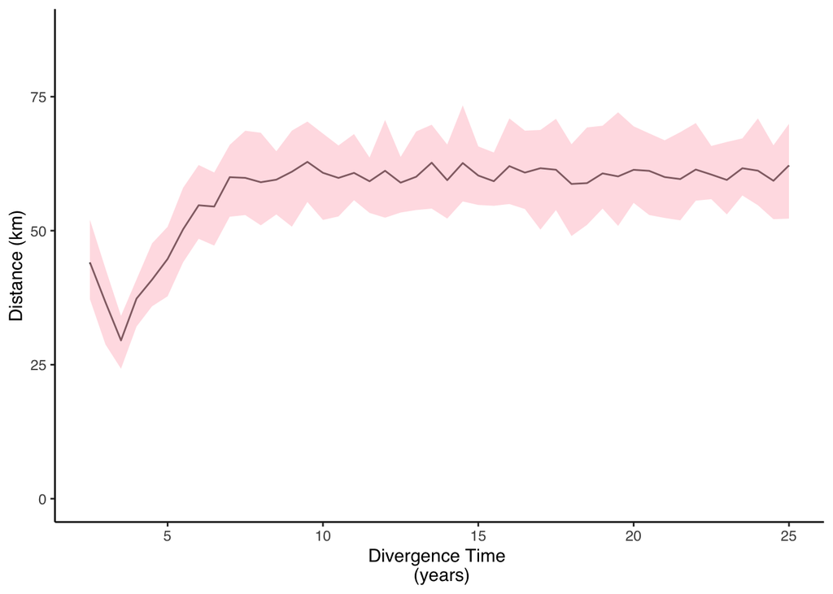

```r
gpsc6_dist_div <- ggplot(gpsc6_Dtime_Dist_CI_posterior_tree$window_divtime_dist, aes(x=mid_win, y=distance.mean, ymin=distance.lowerci, ymax=distance.upperci))+
  geom_line()+
  geom_ribbon(fill="pink", alpha=0.5)+
  #xlim(0,60)+
  xlab("Divergence Time \n (years)")+
  ylab("Distance (km)")+
  ylim(c(0,87))+
  theme(panel.background = element_blank(), axis.line = element_line(colour = "black"), text = element_text(family = "Helvetica"))

gpsc6_dist_div
```

### Relative risk of Spread: Lineage v.s. District

```r
rr_lineage_location_mat = RR_matrix(selected_gpsc_metadata, multitrees)

colyear_mat_ones = matrix(1, nrow=dim(selected_gpsc_metadata)[1], ncol=dim(selected_gpsc_metadata)[1])  ## don't select by collection year
rr = RR_bootstrap(metadataset = selected_gpsc_metadata,
                  des_geo_matrix = rr_lineage_location_mat$des_location_mat,
                  ref_geo_matrix = rr_lineage_location_mat$ref_location_mat,
                  des_strain_matrix = rr_lineage_location_mat$des_lineage_mat,
                  ref_strain_matrix = rr_lineage_location_mat$ref_lineage_mat,
                  colyear_mat_ones, nboot = 100, subsample_min = 70)

## load library: ggplot2
district_lineage_rr = PltRR(rr, "Within District Relative Ratio", "District")

# metadata: metadata
lineage_matrix <- RR_matrix_notree(meta_table = metadata)

colyear_mat_ones = matrix(1, nrow=dim(metadata)[1], ncol=dim(metadata)[1])  ## don't select by collection year
rr = RR_bootstrap(metadataset = metadata,
                  des_geo_matrix = lineage_matrix$des_location_mat,
                  ref_geo_matrix = lineage_matrix$ref_location_mat,
                  des_strain_matrix = lineage_matrix$des_lineage_mat,
                  ref_strain_matrix = lineage_matrix$ref_lineage_mat,
                  colyear_mat_ones, nboot = 100, subsample_min = 70)

district_lineage_rr = PltRR(rr, "Within District Relative Ratio", "District")
```

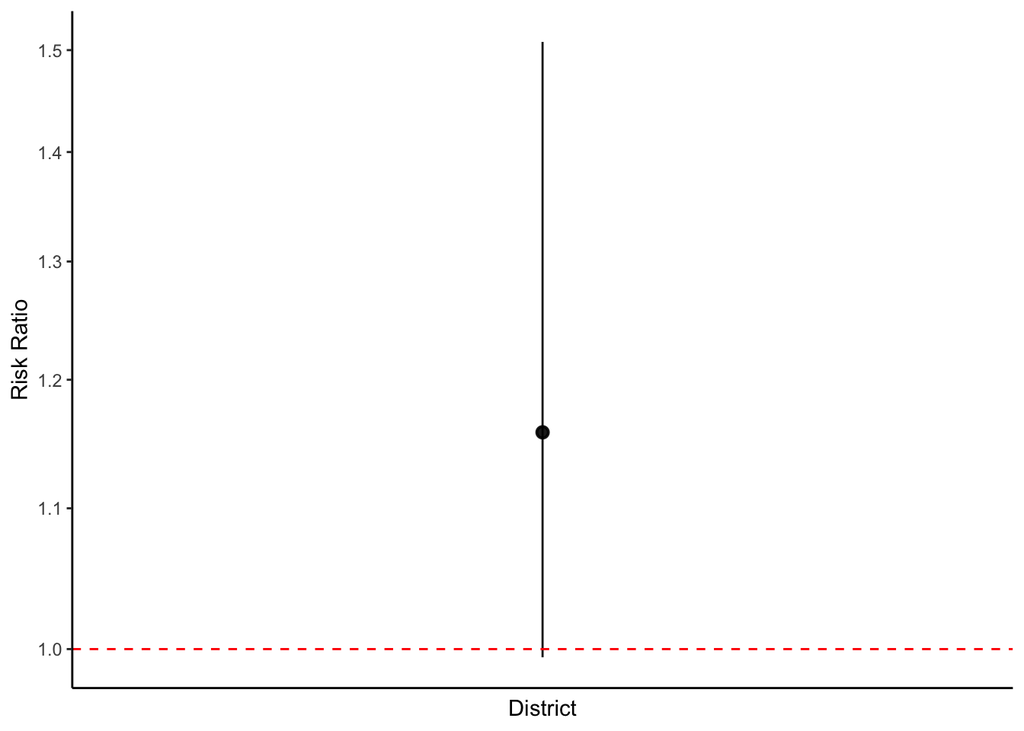

```r
district_lineage_rr
```

### Relative risk of Spread: Lineage v.s. Physical Distance

```r
des_distance_min1 = c(0,1)
des_distance_min2 = seq(from=5, to=25, by=5)
des_distance_min3 = seq(from=30, to=90, by=10)
des_distance_min = append(append(des_distance_min1, des_distance_min2), des_distance_min3)
des_distance_max1 = c(1,5)
des_distance_max2 = seq(from=10, to=30, by=5)
des_distance_max3 = seq(from=40, to=100, by=10)
des_distance_max = append(append(des_distance_max1, des_distance_max2), des_distance_max3)

des_distance_range = length(des_distance_max)

res_list = c()
res_df = data.frame()

colyear_mat_ones = matrix(1, nrow=dim(metadata)[1], ncol=dim(metadata)[1])
diag(colyear_mat_ones) <- NA

RRplotLists = list()
RRdistanceLists = list()
RRdframLists = list()

for(distances in 1:des_distance_range){
  distance_name = paste0("Distance: ",des_distance_min[distances],"~",des_distance_max[distances],"km")
  dist_lineage_mat = RR_matrix_notree(meta_table = metadata,
                               des_distance_min = des_distance_min[distances],
                               des_distance_max = des_distance_max[distances],
                               ref_distance_min = 50, ref_distance_max = 300)
  dist_lineage_mat_rr = RR_bootstrap(metadataset = metadata,
                                     des_geo_matrix = dist_lineage_mat$des_distance_mat,
                                     ref_geo_matrix = dist_lineage_mat$ref_distance_mat,
                                     des_strain_matrix = dist_lineage_mat$des_lineage_mat,
                                     ref_strain_matrix = dist_lineage_mat$ref_lineage_mat,
                                     colyear_matrix = colyear_mat_ones,
                                     nboot = 100,
                                     subsample_min = 100)
  rr_plot = PltRR(dist_lineage_mat_rr, distance_name, distance_name)
  RRplotLists[[distances]] = print(rr_plot)

  distances_col = data.frame(distance_min=des_distance_min[distances], distance_max=des_distance_max[distances], distance_mid = (des_distance_min[distances]+des_distance_max[distances])/2)
  new_row = cbind(dist_lineage_mat_rr, distances_col)
  res_df = rbind(res_df, new_row)

  assign(distance_name, rr_plot)
  res_list=c(res_list, distance_name)
}
```

### Figure 2: Combine Plots 1. [Lineage vs. District] & Plot 2. [Lineage vs. Physical Distance]

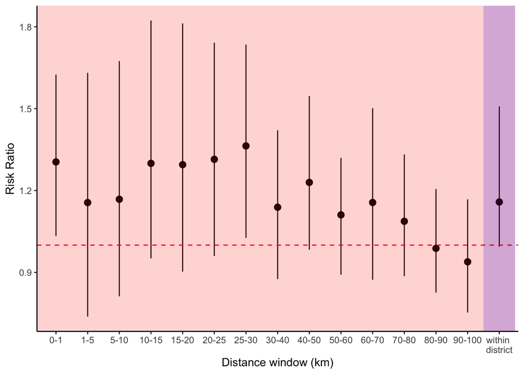

```r
dist_district_lineage_rr_table <- rbind(res_df, rr, fill=TRUE)
for(i in 1:nrow(dist_district_lineage_rr_table)){
  dist_district_lineage_rr_table[i, "distance_window"] = paste0(dist_district_lineage_rr_table[i, "distance_min"],"-" ,dist_district_lineage_rr_table[i, "distance_max"])
}
dist_district_lineage_rr_table[nrow(dist_district_lineage_rr_table), "distance_window"] = "within \ndistrict"
dist_district_lineage_rr_table$distance_window = as.factor(dist_district_lineage_rr_table$distance_window)


#png(filename = "/Users/hc14/Documents/SpneumoIsrael/analysis_results/figures/rolling_distance_RR.png", res=1200, width = 5000, height = 3000)
dist_district_lineage_rr_table$distance_window <- ordered(dist_district_lineage_rr_table$distance_window, levels=c("0-1", "1-5", "5-10", "10-15", "15-20", "20-25", "25-30", "30-40", "40-50", "50-60", "60-70", "70-80", "80-90", "90-100", "within \ndistrict"))
rolling_distance_RR_plot_50km <- ggplot(dist_district_lineage_rr_table, aes(x=distance_window, y=RR_mean))+
  geom_pointrange(data=dist_district_lineage_rr_table, mapping=aes(x=as.factor(distance_window), y=RR_mean, ymin = RR_lower_ci, ymax = RR_upper_ci), alpha=0.9) +
  geom_hline(yintercept=1, linetype="dashed", color = "red") + ##dashed line at 1
  #scale_y_log10()+
  ylab("Risk Ratio")+
  xlab("Distance window (km)")+
  theme(panel.grid.major = element_blank(), panel.grid.minor = element_blank(),
        panel.background = element_blank(), axis.line = element_line(colour = "black"))+
  geom_rect(xmin = 14.5, xmax = 15.5, ymin = -1,  ymax = 5,
            fill = 'blue', alpha = 0.01) +
  geom_rect(xmin = 0, xmax = 15.5, ymin = -1, ymax = 5,
            fill = 'red', alpha = 0.01)

rolling_distance_RR_plot_50km
```

### Rolling divergence vs. relative ratio | Within district vs. Between districts

```r
des_divtime_min1 = seq(from=0, to=8, by=2)
des_divtime_min2 = seq(from=10, to=15, by=5)
des_divtime_min = c(des_divtime_min1, des_divtime_min2, 20)
des_divtime_max1 = seq(from=2, to=10, by=2)
des_divtime_max2 = seq(from=15, to=20, by=5)
des_divtime_max = c(des_divtime_max1, des_divtime_max2, 30)
des_divtime_range = length(des_divtime_max)

res_list = c()
res_df_divtime = data.frame()

colyear_mat_ones = matrix(1, nrow=dim(selected_gpsc_metadata)[1], ncol=dim(selected_gpsc_metadata)[1])
diag(colyear_mat_ones) <- NA

RRplotLists = list()
RRdivtimeLists = list()
RRdframLists = list()

for(divtimes in 1:des_divtime_range){
  divtime_name = paste0("Divergence: ",des_divtime_min[divtimes],"-",des_divtime_max[divtimes],"yrs")
  loc_divtime_mat = RR_matrix(meta_table = selected_gpsc_metadata, bactdate_tree = multitrees,
                              des_divtime_min = des_divtime_min[divtimes],
                              des_divtime_max = des_divtime_max[divtimes])
  loc_divtime_mat_rr = RR_bootstrap(metadataset = selected_gpsc_metadata,
                                    des_geo_matrix = loc_divtime_mat$des_location_mat,
                                    ref_geo_matrix = loc_divtime_mat$ref_location_mat,
                                    des_strain_matrix = loc_divtime_mat$des_divtime_mat,
                                    ref_strain_matrix = loc_divtime_mat$ref_divtime_mat,
                                    colyear_matrix = colyear_mat_ones,
                                    nboot = 100,
                                    subsample_min = 70)
  rr_plot = PltRR(loc_divtime_mat_rr, divtime_name, divtime_name)
  RRplotLists[[divtimes]] = print(rr_plot)

  divtimes_col = data.frame(divtime_min=des_divtime_min[divtimes], divtime_max=des_divtime_max[divtimes], divtime_mid = (des_divtime_min[divtimes]+des_divtime_max[divtimes])/2)
  new_row = cbind(loc_divtime_mat_rr, divtimes_col)
  res_df_divtime = rbind(res_df_divtime, new_row)

  assign(divtime_name, rr_plot)
  res_list=c(res_list, divtime_name)
}
```

```r
#write.table(res_df_divtime, "rolling_distance_divtime_district.txt", sep = "\t", quote = FALSE, row.names =FALSE, col.names = TRUE)

rolling_distance_divtime <- PltRR_rolling_divtime(res_df_divtime,"rolling divergence")+
  scale_x_discrete(labels = c("0-2", "2-4", "4-6", "6-8", "8-10", "10-15", "15-20", "20-30"))+
  #scale_y_continuous(breaks = c(0.5, 1, 1.5, 2, 2.5, 3, 3.5, 4, 4.5, 5), labels = c("0.5", "1.0", "1.5", "2.0", "2.5", "3.0", "3.5", "4.0", "4.5", "5.0"))+
  scale_y_log10(limits=c(0.1,7))+
  ggtitle("By District")+
  theme(axis.text = element_text(size=18),title = element_text(size=20))
```

### Figure Rolling divergence vs. relative ratio | By District

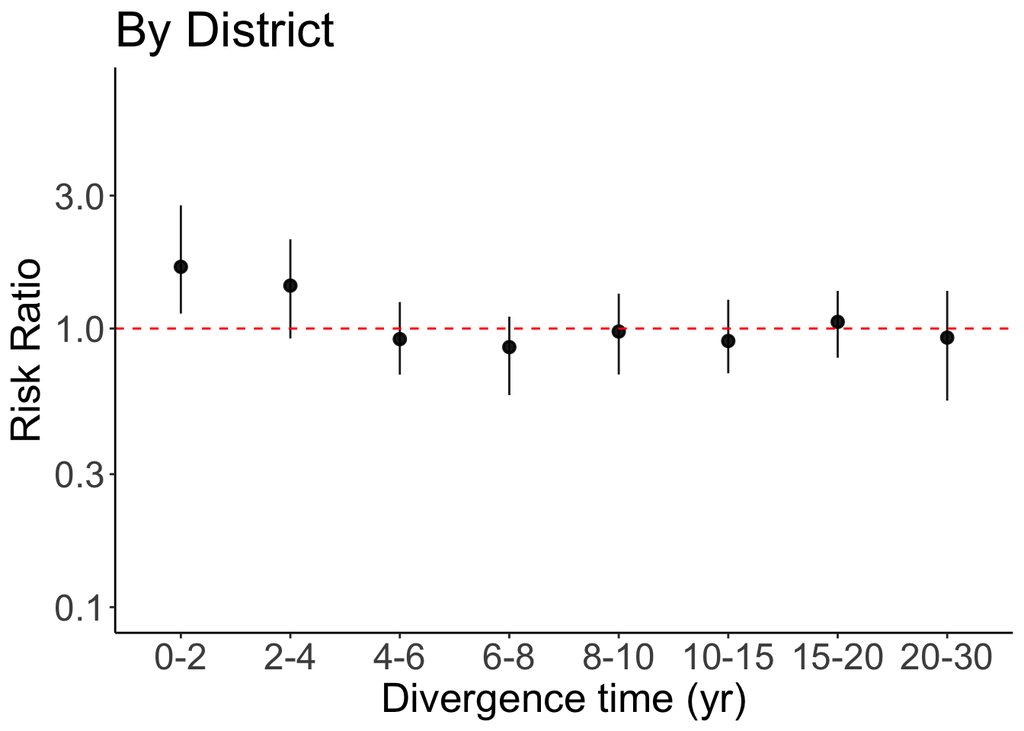

```r
rolling_distance_divtime
```

### Rolling divergence vs. relative ratio | Close area (0-30 km) vs. Distant area

```r
des_divtime_min1 = seq(from=0, to=8, by=2)
des_divtime_min2 = seq(from=10, to=15, by=5)
des_divtime_min = c(des_divtime_min1, des_divtime_min2, 20)
des_divtime_max1 = seq(from=2, to=10, by=2)
des_divtime_max2 = seq(from=15, to=20, by=5)
des_divtime_max = c(des_divtime_max1, des_divtime_max2, 30)
des_divtime_range = length(des_divtime_max)

res_list = c()
res_df = data.frame()

colyear_mat_ones = matrix(1, nrow=dim(selected_gpsc_metadata)[1], ncol=dim(selected_gpsc_metadata)[1])
diag(colyear_mat_ones) <- NA

RRplotLists = list()
RRdivtimeLists = list()
RRdframLists = list()

for(divtimes in 1:des_divtime_range){
  divtime_name = paste0("Divergence: ",des_divtime_min[divtimes],"~",des_divtime_max[divtimes],"yrs")
  loc_divtime_mat = RR_matrix(meta_table = selected_gpsc_metadata, bactdate_tree = multitrees,
                              des_divtime_min = des_divtime_min[divtimes],
                              des_divtime_max = des_divtime_max[divtimes],
                              des_distance_min = 0,
                              des_distance_max = 30,
                              ref_distance_min = 150,
                              ref_distance_max = 300)
  loc_divtime_mat_rr = RR_bootstrap(metadataset = selected_gpsc_metadata,
                                    des_geo_matrix = loc_divtime_mat$des_distance_mat,
                                    ref_geo_matrix = loc_divtime_mat$ref_distance_mat,
                                    des_strain_matrix = loc_divtime_mat$des_divtime_mat,
                                    ref_strain_matrix = loc_divtime_mat$ref_divtime_mat,
                                    colyear_matrix = colyear_mat_ones,
                                    nboot = 100,
                                    subsample_min = 70)
  rr_plot = PltRR(loc_divtime_mat_rr, divtime_name, divtime_name)
  RRplotLists[[divtimes]] = print(rr_plot)

  divtimes_col = data.frame(divtime_min=des_divtime_min[divtimes], divtime_max=des_divtime_max[divtimes], divtime_mid = (des_divtime_min[divtimes]+des_divtime_max[divtimes])/2)
  new_row = cbind(loc_divtime_mat_rr, divtimes_col)
  res_df = rbind(res_df, new_row)

  assign(divtime_name, rr_plot)
  res_list=c(res_list, divtime_name)
}
```

```r
#write.table(res_df, "/Users/hc14/Documents/SpneumoIsrael/analysis_results/figures/figure4/rolling_distance_divtime_30km_150kmRef.txt", sep = "\t", quote = FALSE, row.names =FALSE, col.names = TRUE)

rolling_distance_divtime_30km_150kmRef <- PltRR_rolling_divtime(res_df,"rolling divergence")+
  scale_x_discrete(labels = c("0-2", "2-4", "4-6", "6-8", "8-10", "10-15", "15-20", "20-30"))+
  #scale_y_continuous(breaks = c(0.5, 1, 1.5, 2, 3, 4, 5, 6, 7), labels = c("0.5", "1.0", "1.5", "2.0", "3.0",  "4.0", "5.0", "6.0", "7.0"))+
  scale_y_log10(limits=c(0.1,60))+
  ggtitle("By Distance")+
  theme(axis.text = element_text(size=18),title = element_text(size=20))

#png("/Users/hc14/Documents/SpneumoIsrael/analysis_results/figures/figure4/rolling_divtime_30km_150kmRef.png")
#rolling_distance_divtime_30km_150kmRef
#dev.off()
```

### Figure: Rolling divergence vs. relative ratio | By Distance

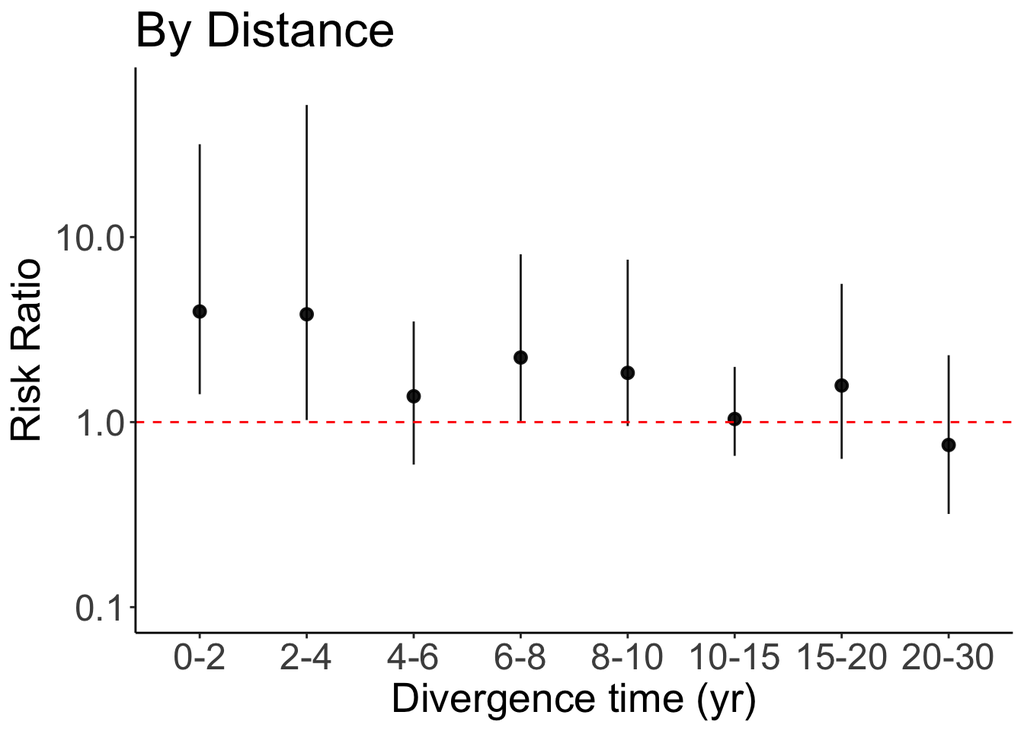

```r
rolling_distance_divtime_30km_150kmRef
```

### Figure 4: rolling divergence vs. relative risk ratio

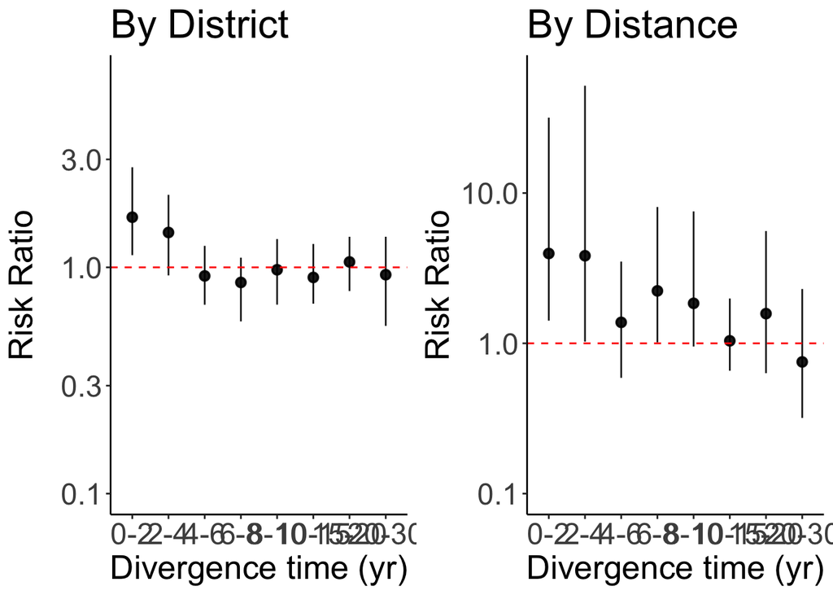

```r
rolling_divergence_rr <- plot_grid(rolling_distance_divtime, NULL,rolling_distance_divtime_30km_150kmRef, rel_widths=c(1,0,1),rel_heights=c(1,0,1), scale=c(1,0,1), align = "hv", nrow = 1)

#png("/Users/hc14/Documents/SpneumoIsrael/analysis_results/figures/figure4/figure4_30km_100kmRef.png", width = 1000, height = 300)
rolling_divergence_rr
```

```r
#dev.off()


#rolling_divergence_rr_sensitive <- plot_grid(rolling_distance_divtime_30km_0kmRef,rolling_distance_divtime_30km_50kmRef, rolling_distance_divtime_30km_80kmRef, rel_widths=c(1,1,1),rel_heights=c(1,1,1), scale=c(1,1,1), align = "hv", nrow = 2, labels = "AUTO")

#png("/Users/hc14/Documents/SpneumoIsrael/analysis_results/figures/figure4/rolling_divergence_rr_sensitive.png", width = 1600, height = 800)
#rolling_divergence_rr_sensitive
#dev.off()
```